# Tugas Pertemuan 3 MPDW

# Pemanggilan Packages

```r
library(readxl)
library(TTR)
library(forecast)
library(dplyr)
library(lmtest)
library(orcutt)
library(HoRM)
```

# IMPOR DATA

```r
dataku <- read_xlsx("/Users/mrkahar/Downloads/MPDW K2.xlsx", sheet = "jambi")
dataku
```

```
## # A tibble: 15 × 2
##    Tahun   IPM
##    <dbl> <dbl>
##  1  2010  65.4
##  2  2011  66.1
##  3  2012  66.9
##  4  2013  67.8
##  5  2014  68.2
##  6  2015  68.9
##  7  2016  69.6
##  8  2017  70.0
##  9  2018  70.6
## 10  2019  71.3
## 11  2020  71.3
## 12  2021  71.6
## 13  2022  72.1
## 14  2023  72.8
## 15  2024  73.4
```

```r
# Membuat data time series
data.ts<-ts(dataku$IPM)
data.ts
```

```
## Time Series:
## Start = 1
## End = 15
## Frequency = 1
##  [1] 65.39 66.14 66.94 67.76 68.24 68.89 69.62 69.99 70.65 71.26 71.29 71.63
## [13] 72.14 72.77 73.43
```

# EKSPLORASI DATA

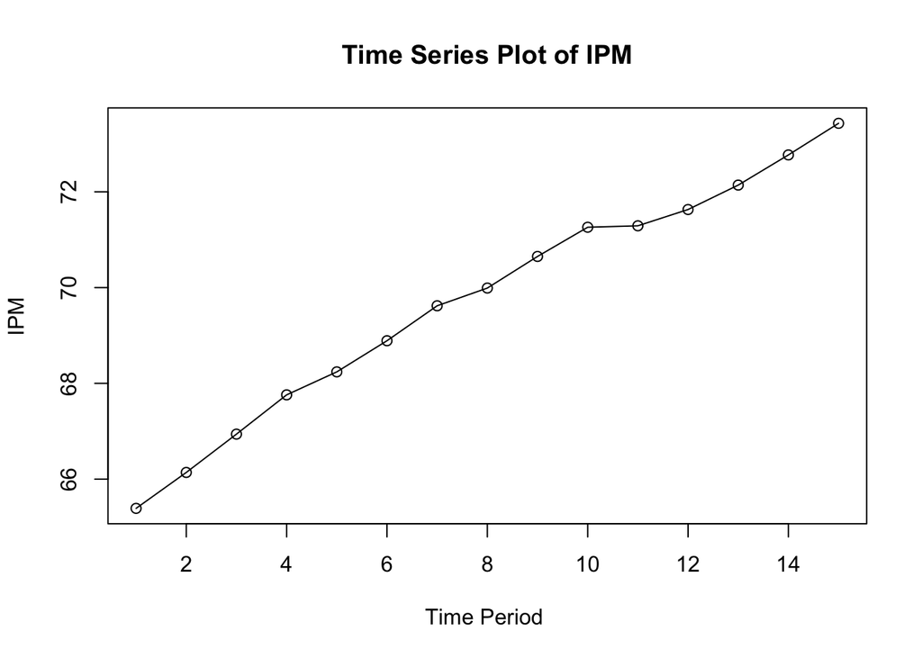

```r
# Membuat plot time series
ts.plot(data.ts, xlab="Time Period ", ylab="IPM", main= "Time Series Plot of IPM")
points(data.ts)
```

**Interpretasi :** Berdasarkan plot time series, dapat dilihat bahwa **terdapat tren** pada data sehingga akan dilakukan peramlaan dan pemulusan dengan metode DMA dan DES.

## Double Moving Average (DMA)

```r
dt.sma <- SMA(data.ts, n=3)
dma <- SMA(dt.sma, n = 3)
At <- 2*dt.sma - dma
Bt <- 2/(3-1)*(dt.sma - dma)
dt.dma<- At+Bt
dt.ramal<- c(NA, dt.dma)

t = 1:5
f = c()

for (i in t) {
  f[i] = At[length(At)] + Bt[length(Bt)]*(i)
}

dt.gab <- cbind(aktual = c(data.ts,rep(NA,5)),
                pemulusan1 = c(dt.sma,rep(NA,5)),
                pemulusan2 = c(dt.dma, rep(NA,5)),
                At = c(At, rep(NA,5)),
                Bt = c(Bt,rep(NA,5)),
                ramalan = c(dt.ramal, f[-1]))
dt.gab
```

```
##       aktual pemulusan1 pemulusan2       At        Bt  ramalan
##  [1,]  65.39         NA         NA       NA        NA       NA
##  [2,]  66.14         NA         NA       NA        NA       NA
##  [3,]  66.94   66.15667         NA       NA        NA       NA
##  [4,]  67.76   66.94667         NA       NA        NA       NA
##  [5,]  68.24   67.64667   69.10667 68.37667 0.7300000       NA
##  [6,]  68.89   68.29667   69.63000 68.96333 0.6666667 69.10667
##  [7,]  69.62   68.91667   70.17667 69.54667 0.6300000 69.63000
##  [8,]  69.99   69.50000   70.69111 70.09556 0.5955556 70.17667
##  [9,]  70.65   70.08667   71.25778 70.67222 0.5855556 70.69111
## [10,]  71.26   70.63333   71.75333 71.19333 0.5600000 71.25778
## [11,]  71.29   71.06667   72.00889 71.53778 0.4711111 71.75333
## [12,]  71.63   71.39333   72.11778 71.75556 0.3622222 72.00889
## [13,]  72.14   71.68667   72.29556 71.99111 0.3044444 72.11778
## [14,]  72.77   72.18000   73.03333 72.60667 0.4266667 72.29556
## [15,]  73.43   72.78000   73.90889 73.34444 0.5644444 73.03333
## [16,]     NA         NA         NA       NA        NA 73.90889
## [17,]     NA         NA         NA       NA        NA 74.47333
## [18,]     NA         NA         NA       NA        NA 75.03778
## [19,]     NA         NA         NA       NA        NA 75.60222
## [20,]     NA         NA         NA       NA        NA 76.16667
```

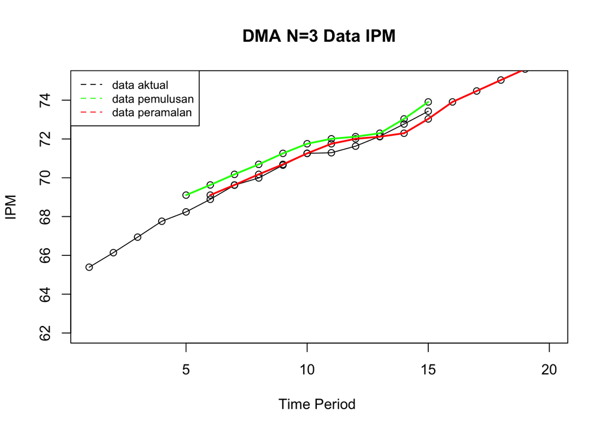

```r
# Membuat plot time series
ts.plot(dt.gab[,1], xlab="Time Period ", ylab="IPM",
        main= "DMA N=3 Data IPM", ylim=c(62,75))
points(dt.gab[,1])
points(dt.gab[,3])
points(dt.gab[,6])
lines(dt.gab[,3],col="green",lwd=2)
lines(dt.gab[,6],col="red",lwd=2)
legend("topleft",c("data aktual","data pemulusan","data peramalan"),
       lty=8, col=c("black","green","red"), cex=0.8)
```

```r
# Menghitung nilai keakuratan
error.dma = data.ts-dt.ramal[1:length(data.ts)]
SSE.dma = sum(error.dma[6:length(data.ts)]^2)
MSE.dma = mean(error.dma[6:length(data.ts)]^2)
MAPE.dma = mean(abs((error.dma[6:length(data.ts)]/data.ts[6:length(data.ts)])*100))

akurasi.dma <- matrix(c(SSE.dma, MSE.dma, MAPE.dma))
row.names(akurasi.dma)<- c("SSE", "MSE", "MAPE")
colnames(akurasi.dma) <- c("Akurasi m = 3")
akurasi.dma
```

```
##      Akurasi m = 3
## SSE     0.82475432
## MSE     0.08247543
## MAPE    0.30587475
```

## Double Exponential Smoothing (DES)

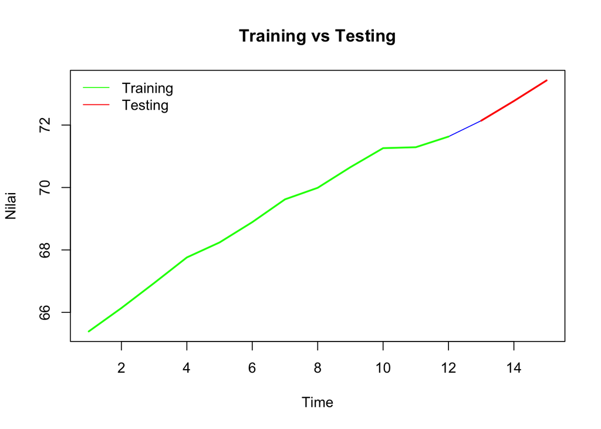

```r
# Membagi data training dan testing
training<-dataku[1:12,2]
testing<-dataku[13:15,2]

# Membuat data time series
training.ts<-ts(training)
testing.ts<-ts(testing,start=13)

# Definisikan semua data
data.ts <- ts(dataku[,2])

# Membuat plot data training dan testing
plot(data.ts, col="blue", main="Training vs Testing", ylab="Nilai")
lines(training.ts, col="green", lwd=2)
lines(testing.ts, col="red", lwd=2)
legend("topleft", legend=c("Training","Testing"),
       col=c("green","red"), lty=1, bty="n")
```

```r
# Pemulusan dengan lambda dan gamma optimum
des.opt<- HoltWinters(training.ts, gamma = FALSE)
des.opt
```

```
## Holt-Winters exponential smoothing with trend and without seasonal component.
##
## Call:
## HoltWinters(x = training.ts, gamma = FALSE)
##
## Smoothing parameters:
##  alpha: 0.5120948
##  beta : 1
##  gamma: FALSE
##
## Coefficients:
##         [,1]
## a 71.7433379
## b  0.2063202
```

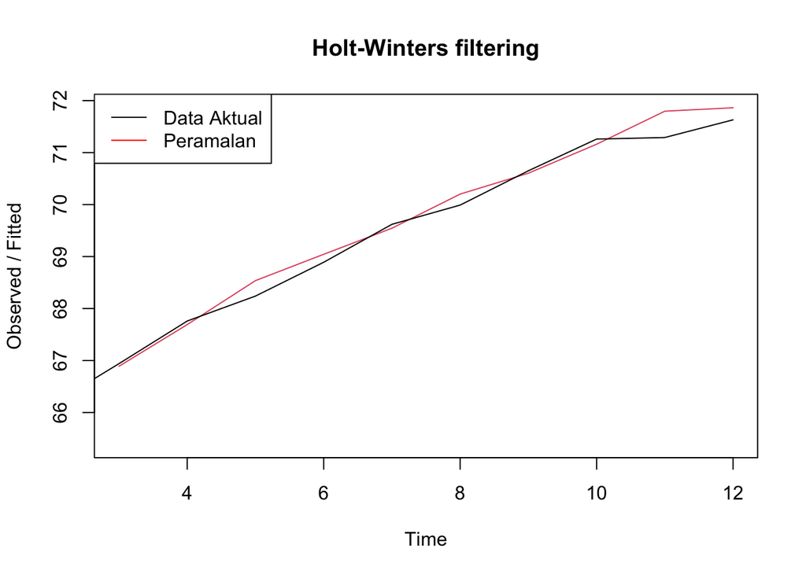

```r
plot(des.opt)
legend("topleft", c("Data Aktual", "Peramalan"), col = c("black", "red"),
       lty = c(1,1))
```

```r
# Ramalan
ramalandesopt<- forecast(des.opt, h=5)
ramalandesopt
```

```
##    Point Forecast    Lo 80    Hi 80    Lo 95    Hi 95
## 13       71.94966 71.68660 72.21272 71.54734 72.35198
## 14       72.15598 71.77943 72.53253 71.58009 72.73187
## 15       72.36230 71.80992 72.91467 71.51751 73.20709
## 16       72.56862 71.79694 73.34029 71.38845 73.74879
## 17       72.77494 71.75065 73.79923 71.20842 74.34145
```

```r
# Akurasi data training
ssedes.train<-des.opt$SSE
msedes.train<-ssedes.train/length(training.ts)
sisaandes<-ramalandesopt$residuals

mapedes.train <- sum(abs(sisaandes[3:length(training.ts)]/training.ts[3:length(training.ts)])*100)/length(training.ts)

akurasides.opt <- matrix(c(ssedes.train,msedes.train,mapedes.train))
row.names(akurasides.opt)<- c("SSE", "MSE", "MAPE")
colnames(akurasides.opt) <- c("Akurasi lambda dan gamma optimum")
akurasides.opt
```

```
##      Akurasi lambda dan gamma optimum
## SSE                        0.49193268
## MSE                        0.04099439
## MAPE                       0.20705870
```

```r
# Akurasi data testing
selisihdesopt<-ramalandesopt$mean-testing.ts
selisihdesopt
```

```
## Time Series:
## Start = 13
## End = 15
## Frequency = 1
##      testing.ts
## [1,] -0.1903419
## [2,] -0.6140217
## [3,] -1.0677015
```

```r
SSEtestingdesopt<-sum(selisihdesopt^2)
SSEtestingdesopt<-SSEtestingdesopt/length(testing.ts)
MAPEtestingdesopt<-sum(abs(selisihdesopt/testing.ts)*100)/length(testing.ts)

akurasiDesTesting <- matrix(c(SSEtestingdesopt,SSEtestingdesopt,MAPEtestingdesopt))
row.names(akurasiDesTesting)<- c("SSE", "MSE", "MAPE")
colnames(akurasiDesTesting) <- c("Akurasi lambda dan gamma optimum")
akurasiDesTesting
```

```
##      Akurasi lambda dan gamma optimum
## SSE                         0.5177464
## MSE                         0.5177464
## MAPE                        0.8538916
```

### Perbandingan

```r
cbind(akurasi.dma, akurasides.opt)
```

```
##      Akurasi m = 3 Akurasi lambda dan gamma optimum
## SSE     0.82475432                       0.49193268
## MSE     0.08247543                       0.04099439
## MAPE    0.30587475                       0.20705870
```

**Interpretasi:** Berdasarkan perbandingan akurasi, dapat dilihat bahwa nilai SSE, MSE, dan MAPE metode DES lebih kecil dibandingkan dengan metode DMA. Oleh Karena itu, **metode peramalan dan pemulusan yang paling baik adalah metode DES.**

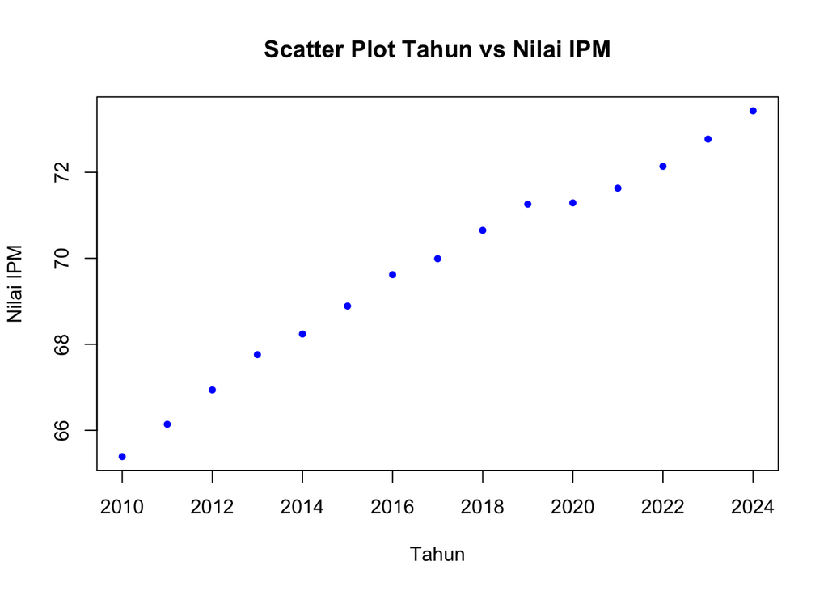

```r
# Membuat Scatter Plot
plot(dataku$Tahun,dataku$IPM, pch = 20, col = "blue",
     main = "Scatter Plot Tahun vs Nilai IPM",
     xlab = "Tahun",
     ylab = "Nilai IPM")
```

```r
# Menampilkan Nilai Korelasi
cor(dataku$Tahun,dataku$IPM)
```

```
## [1] 0.9919795
```

**Interpretasi:** Berdasarkan scatter plot, dapat dilihat adanya **hubungan positif** antara peubah tahun dan nilai IPM Provinsi Jambi. hal ini diperkuat nilai korelasi sebesar **0.992 (positif kuat).**

# PEMODELAN REGRESI

```r
model <- lm(IPM~Tahun, data = dataku)
summary(model)
```

```
##
## Call:
## lm(formula = IPM ~ Tahun, data = dataku)
##
## Residuals:
##      Min       1Q   Median       3Q      Max
## -0.54117 -0.26517 -0.08017  0.24183  0.42833
##
## Coefficients:
##               Estimate Std. Error t value Pr(>|t|)
## (Intercept) -1.029e+03  3.881e+01   -26.5 1.06e-12 ***
## Tahun        5.445e-01  1.924e-02    28.3 4.60e-13 ***
## ---
## Signif. codes:  0 '***' 0.001 '**' 0.01 '*' 0.05 '.' 0.1 ' ' 1
##
## Residual standard error: 0.322 on 13 degrees of freedom
## Multiple R-squared:  0.984,  Adjusted R-squared:  0.9828
## F-statistic: 800.7 on 1 and 13 DF,  p-value: 4.595e-13
```

**Interpretasi :**

1. Model yang dihasilkan adalah
   $$\hat{IPM} = -1029 + 0.5445Tahun$$
2. Pada ringkasan model, dapat dilihat bahwa hasil uji F memiliki nilai p < -.05. Artinya, minimal ada satu peubah yang berpengaruh nyata terhadap model pada taraf nyata 5%.
3. Hasil uji-t parsial kedua parameter regresi, yaitu intersep dan slope juga menunjukkan hal yang serupa yaitu nilai p < 0.05. Artinya, **intersep dan slope berpengaruh nyata** terhadap model pada taraf nyata 5%.
4. Nilai R-squared sebesar 0.9828 memiliki arti bahwa **98.28%** keragaman nilai IPM dapat dijelaskan oleh peubah tahun.

### Uji Sisaan

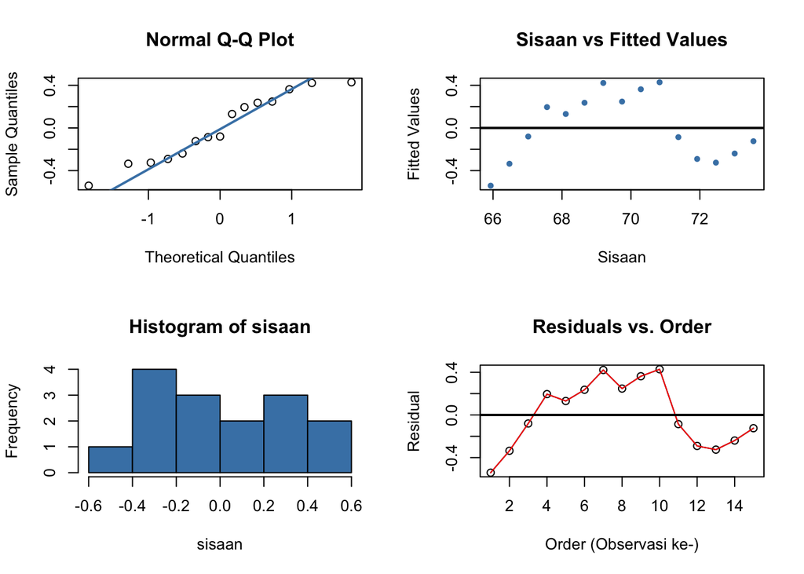

```r
# Sisaan dan fitted value
sisaan<- residuals(model)
fitValue<- predict(model)

# Diagnostik dengan eksploratif
par(mfrow = c(2,2))
qqnorm(sisaan)
qqline(sisaan, col = "steelblue", lwd = 2)
plot(fitValue, sisaan, col = "steelblue", pch = 20, xlab = "Sisaan", ylab = "Fitted Values", main = "Sisaan vs Fitted Values")
abline(a = 0, b = 0, lwd = 2)
hist(sisaan, col = "steelblue")
plot(sisaan, type = "o", main = "Residuals vs. Order",
     xlab = "Order (Observasi ke-)", ylab = "Residual")
lines(seq(1,15,1), sisaan, col = "red")
abline(a = 0, b = 0, lwd = 2)
```

**Interpretasi:**

1. Normal Q-Q Plot dan histogram dari sisaan menunjukkan bahwa **sisaan cenderung menyebar normal.**
2. Plot sisaan vs fitted value dan plot sisaan vs order menunjukkan **adanya pola pada sisaan** yang mengindikasikan adanya autokorelasi.

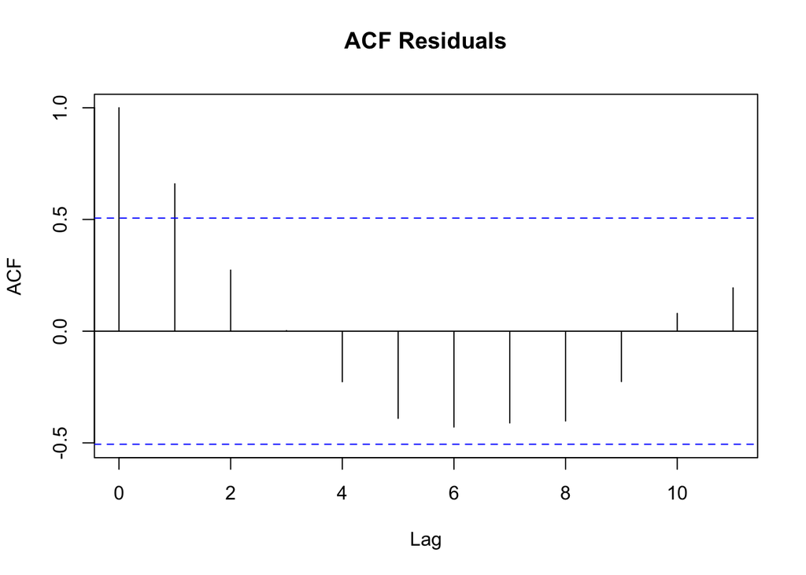

```r
# Plot ACF dan PACF
acf(sisaan, main = "ACF Residuals")
```

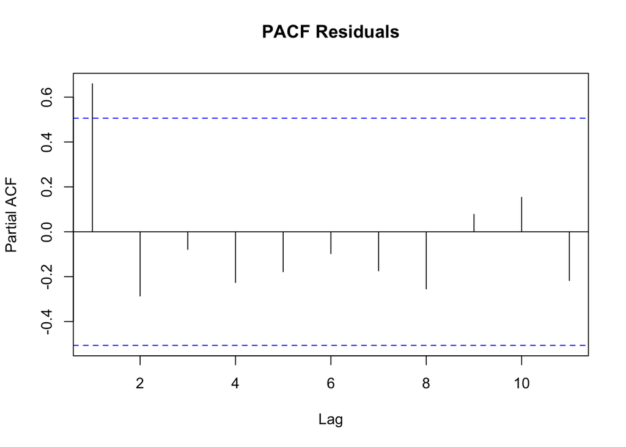

```r
pacf(sisaan, main = "PACF Residuals")
```

### Uji Formal

```r
# Uji Normalitas
shapiro.test(sisaan)
```

```
##
##  Shapiro-Wilk normality test
##
## data:  sisaan
## W = 0.938, p-value = 0.3579
```

```r
ks.test(sisaan, "pnorm", mean=mean(sisaan), sd=sd(sisaan))
```

```
##
##  Exact one-sample Kolmogorov-Smirnov test
##
## data:  sisaan
## D = 0.1355, p-value = 0.9117
## alternative hypothesis: two-sided
```

```r
# H0: tidak ada autokorelasi
# H1: ada autokorelasi
dwtest(model)
```

```
##
##  Durbin-Watson test
##
## data:  model
## DW = 0.45226, p-value = 6.727e-06
## alternative hypothesis: true autocorrelation is greater than 0
```

**Interpretasi:**

1. Berdasarkan uji formal Shapiro-Wilk dan Kolmogorov-Smirnov diperoleh nilai p > 0.05. Artinya, terdapat cukup bukti untuk menyatakan **sisaan menyebar normal** pada taraf nyata 5%.
2. Berdasarkan uji formal Durbin-Watson diperoleh nilai p < 0.05. Artinya, terdapat cukup bukti untuk menyatakan bahwa **ada autokorelasi** pada taraf nyata 5%. Oleh sebab itu, diperlukan penanganan autokorelasi.

# PENANGANAN AUTOKORELASI

## Metode Cochrane-Orcutt

```r
# Pemodelan
modelCO<-cochrane.orcutt(model)
modelCO
```

```
## Cochrane-orcutt estimation for first order autocorrelation
##
## Call:
## lm(formula = IPM ~ Tahun, data = dataku)
##
##  number of interaction: 31
##  rho 0.67851
##
## Durbin-Watson statistic
## (original):    0.45226 , p-value: 6.727e-06
## (transformed): 1.80503 , p-value: 2.39e-01
##
##  coefficients:
## (Intercept)       Tahun
## -898.889029    0.480367
```

**Interpretasi:**

1. Model yang dihasilkan adalah
   $$\hat{IPM} = -898.889 +
   0.4804Tahun$$
2. Nilai p pada uji formal Durbin-Watson terhadap model hasil transformasi > 0.05. Arinya, **belum cukup bukti** untuk menyatakan bahwa sisaan **ada autokorelasi** pada taraf nyata 5%.

```r
summary(modelCO)
```

```
## Call:
## lm(formula = IPM ~ Tahun, data = dataku)
##
##                Estimate  Std. Error t value  Pr(>|t|)
## (Intercept) -898.889029   71.179601 -12.628 2.733e-08 ***
## Tahun          0.480367    0.035244  13.630 1.156e-08 ***
## ---
## Signif. codes:  0 '***' 0.001 '**' 0.01 '*' 0.05 '.' 0.1 ' ' 1
##
## Residual standard error: 0.1709 on 12 degrees of freedom
## Multiple R-squared:  0.9393 ,  Adjusted R-squared:  0.9343
## F-statistic: 185.8 on 1 and 12 DF,  p-value: < 1.156e-08
##
## Durbin-Watson statistic
## (original):    0.45226 , p-value: 6.727e-06
## (transformed): 1.80503 , p-value: 2.39e-01
```

**Interpretasi:**

1. Pada ringkasan model, dapat dilihat bahwa hasil uji F memiliki nilai p < 0.05. Artinya, minimal ada satu peubah yang berpengaruh nyata terhadap model pada taraf nyata 5%.
2. Hasil uji-t parsial kedua parameter regresi, yaitu intersep dan slope juga menunjukkan hal yang serupa yaitu nilai p < 0.05. Artinya, **intersep dan slope berpengaruh nyata** terhadap model pada taraf nyata 5%.
3. Nilai R-squared sebesar 0.9343 memiliki arti bahwa **93.43%** keragaman nilai IPM dapat dijelaskan oleh peubah tahun.

```r
# Menampilkan nilai rho optimum
rho<- modelCO$rho
rho
```

```
## [1] 0.6785097
```

### Transofrmasi Manual

```r
ipm.trans<- dataku$IPM[-1]-dataku$IPM[-15]*rho
tahun.trans<- dataku$Tahun[-1]-dataku$Tahun[-15]*rho
modelCOmanual<- lm(ipm.trans~tahun.trans)
summary(modelCOmanual)
```

```
##
## Call:
## lm(formula = ipm.trans ~ tahun.trans)
##
## Residuals:
##      Min       1Q   Median       3Q      Max
## -0.35789 -0.10033  0.03164  0.13595  0.19791
##
## Coefficients:
##               Estimate Std. Error t value Pr(>|t|)
## (Intercept) -288.98411   22.88355  -12.63 2.73e-08 ***
## tahun.trans    0.48037    0.03524   13.63 1.16e-08 ***
## ---
## Signif. codes:  0 '***' 0.001 '**' 0.01 '*' 0.05 '.' 0.1 ' ' 1
##
## Residual standard error: 0.1709 on 12 degrees of freedom
## Multiple R-squared:  0.9393, Adjusted R-squared:  0.9343
## F-statistic: 185.8 on 1 and 12 DF,  p-value: 1.156e-08
```

**Interpretasi:** Ringkasan data pada transformasi manual sama dengan ringkasan transformasi dengan packages orcutt.

### Transformasi Balik

```r
b0bintang <- modelCOmanual$coefficients[-2]
b0 <- b0bintang/(1-rho)
b1 <- modelCOmanual$coefficients[-1]
b0
```

```
## (Intercept)
##    -898.889
```

```r
b1
```

```
## tahun.trans
##   0.4803672
```

**Interpretasi:** Model yang dihasilkan adalah
$$\hat{IPM} = -898.889 + 0.4804Tahun$$

## Metode Hildreth-Lu

```r
hildreth.lu.func<- function(r, model){
  x <- model.matrix(model)[,-1]
  y <- model.response(model.frame(model))
  n <- length(y)
  t <- 2:n
  y <- y[t]-r*y[t-1]
  x <- x[t]-r*x[t-1]

  return(lm(y~x))
}

# Mencari nilai rho yang meminimumkan SSE
r <- c(seq(0.1,0.9, by= 0.1))
tab <- data.frame("rho" = r, "SSE" = sapply(r, function(i){deviance(hildreth.lu.func(i, model))}))
round(tab, 4)
```

```
##   rho    SSE
## 1 0.1 0.7948
## 2 0.2 0.6544
## 3 0.3 0.5407
## 4 0.4 0.4535
## 5 0.5 0.3928
## 6 0.6 0.3587
## 7 0.7 0.3511
## 8 0.8 0.3701
## 9 0.9 0.4156
```

**Interpretasi:** Berdasarkan output di atas, dapat dilihat bahwa nilai SSE minimum ketika nilai **rho = 0.7.** Namun, hasil tersebut masih kurang teliti sehingga akan dicari kembali nilai rho yang lebih optimum dengan ketelitian yang leibh.

```r
# Rho optimal di sekitar 0.7
rOpt <- seq(0.6,0.8, by= 0.001)
tabOpt <- data.frame("rho" = rOpt, "SSE" = sapply(rOpt, function(i){deviance(hildreth.lu.func(i, model))}))
head(tabOpt[order(tabOpt$SSE),])
```

```
##      rho       SSE
## 80 0.679 0.3504878
## 79 0.678 0.3504879
## 81 0.680 0.3504905
## 78 0.677 0.3504905
## 82 0.681 0.3504957
## 77 0.676 0.3504959
```

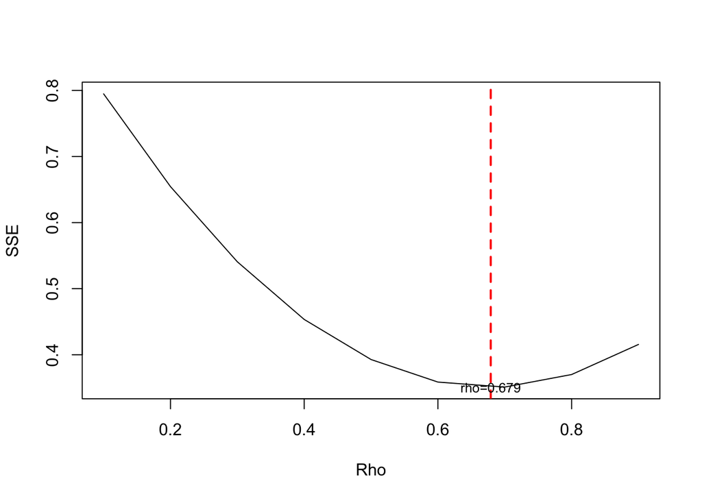

```r
# Plot SSE optimum
par(mfrow = c(1,1))
plot(tab$SSE ~ tab$rho , type = "l", xlab = "Rho", ylab = "SSE")
abline(v = tabOpt[tabOpt$SSE==min(tabOpt$SSE),"rho"], lty = 2, col="red",lwd=2)
text(x=0.679, y=0.3504878, labels = "rho=0.679", cex = 0.8)
```

**Interpretasi :**Nilai rho optimum, yaitu saat nilai SSE terkecil terdapat pada nilai **rho = 0.679.** Hal tersebut juga dapat dilihat pada plot.

```r
# Model terbaik
modelHL <- hildreth.lu.func(0.679, model)
summary(modelHL)
```

```
##
## Call:
## lm(formula = y ~ x)
##
## Residuals:
##     Min      1Q  Median      3Q     Max
## -0.3581 -0.1005  0.0318  0.1361  0.1978
##
## Coefficients:
##              Estimate Std. Error t value Pr(>|t|)
## (Intercept) -288.4757    22.8836  -12.61 2.79e-08 ***
## x              0.4803     0.0353   13.61 1.18e-08 ***
## ---
## Signif. codes:  0 '***' 0.001 '**' 0.01 '*' 0.05 '.' 0.1 ' ' 1
##
## Residual standard error: 0.1709 on 12 degrees of freedom
## Multiple R-squared:  0.9391, Adjusted R-squared:  0.9341
## F-statistic: 185.1 on 1 and 12 DF,  p-value: 1.179e-08
```

**Interpretasi:**

1. Model yang dihasilkan adalah
   $$\hat{IPM} = -288.4757 +
   0.4803Tahun$$
2. Pada ringkasan model, dapat dilihat bahwa hasil uji F memiliki nilai p < -.05. Artinya, minimal ada satu peubah yang berpengaruh nyata terhadap model pada taraf nyata 5%.
3. Hasil uji-t parsial kedua parameter regresi, yaitu intersep dan slope juga menunjukkan hal yang serupa yaitu nilai p < 0.05. Artinya, **intersep dan slope berpengaruh nyata** terhadap model pada taraf nyata 5%.
4. Nilai R-squared sebesar 0.9341 memiliki arti bahwa **93.41%** keragaman nilai IPM dapat dijelaskan oleh peubah tahun.

### Transformasi Balik

```r
cat("y = ", coef(modelHL)[1]/(1-0.639), "+", coef(modelHL)[2],"x", sep = "")
```

```
## y = -799.1016+0.480263x
```

```r
#Deteksi autokorelasi
dwtest(modelHL)
```

```
##
##  Durbin-Watson test
##
## data:  modelHL
## DW = 1.8057, p-value = 0.2394
## alternative hypothesis: true autocorrelation is greater than 0
```

**Interpretasi:** Hasil uji Durbin-Watson menunjukkan bahwa nilai p > 0.05. Artinya, **belum cukup bukti** untuk menyatakan bahwa **ada autokorelasi** pada taraf nyata 5%.

# Perbandingan

```r
sseModelawal <- anova(model)$`Sum Sq`[-1]
sseModelCO <- anova(modelCOmanual)$`Sum Sq`[-1]
sseModelHL <- anova(modelHL)$`Sum Sq`[-1]
mseModelawal <- sseModelawal/length(dataku$IPM)
mseModelCO <- sseModelCO/length(dataku$IPM)
mseModelHL <- sseModelHL/length(dataku$IPM)
akurasi <- matrix(c(sseModelawal,sseModelCO,sseModelHL,
                    mseModelawal,mseModelCO,mseModelHL),nrow=2,ncol=3,byrow = T)
colnames(akurasi) <- c("Model Awal", "Model Cochrane-Orcutt", "Model Hildreth-Lu")
row.names(akurasi) <- c("SSE","MSE")
akurasi
```

```
##     Model Awal Model Cochrane-Orcutt Model Hildreth-Lu
## SSE 1.34782333            0.35048751        0.35048783
## MSE 0.08985489            0.02336583        0.02336586
```

**Interpretasi:** Berdasarkan hasil tersebut, dapat diketahui bahwa hasil penanganan autokorelasi dengan metode Cochrane-Orcutt dan Hildreth-Lu memiliki SSE dan MSE yang sama, yaitu 0.3505 dan 0.02337. Nilai tersebut lebih kecil daripada nilai SSE dan MSE model awal, yaitu 1.3478 dan 0.0898. Artinya **model hasil penanganan autokorelasi dengan metode Cochrane-Orcutt dan Hildreth-Lu lebih baik dibandingkan model awal.**

Zifa Aura Rahman  
G1401231010